# 🩺Pneumonia Detection🔍

👨‍⚕️ [LIVE PROJECT](https://pneumonia-detect-kc.herokuapp.com/) 👩‍⚕️  
💥 [TEST IMAGES](https://pneumonia-detect-kc.herokuapp.com/static/Test_Images.rar) 💥

### Index

- 1. Introduction
  - 1.1 Symptoms
  - 1.2 Causes of Pneumonia Disease
  - 1.3 Risk Factors
  - 1.4 Diagnosis
  - 1.5 Pneumonia Categories
  - 1.6 Stages of Pneumonia
  - 1.7 Interesting Facts
- 2. Problem Statement
- 3. Data Description
- 4. Exploratory Data Analysis(EDA)
  - 4.1 Distribution of Images in train, val and test set
  - 4.2 Review X-Ray Sample Images(Normal and Pneumonia)
    - 4.2.1 Review Normal X-Ray Sample Images
    - 4.2.2 Review Pneumonia X-Ray Sample Images
  - 4.3 Pixel Intensity of Pneumonia and Normal Patient X-Ray Images
    - 4.3.1 Pixel Intensity of Pneumonia Patient X-Ray Images
    - 4.3.2 Pixel Intensity of Normal Patient X-Ray Images
  - 4.4 Exploration of Single Pneumonia Patient Image
  - 4.5 EDA Findings
- 5. Preprocessing
  - 5.1 Defining Train, Val and Test Generators
  - 5.2 Addressing Class Imbalance Problem using Class Weights
  - 5.3 DenseNet121
  - 5.4 Defining Model Checkpoints
- 6. Prediction and Evaluation
  - 6.1 Confusion Matrix
  - 6.2 Accuracy, Loss, AUC, Precision and Recall
  - 6.3 Accuracy and Loss Curve of Training and Validation Set
  - 6.4 ROC Curve, Precision-Recall Curve, F1 Score
  - 6.5 Visualize Model Learning with GradCAM

### 1. Brief Introduction of Pneumonia Disease

[figure not shown]

Pneumonia is an inflammatory condition of the lung affecting primarily the small air sacs known as alveoli.

**`SYMPTOMS`**

- Dry Cough - Pus or Bloody Sputum
- Chest Pain
- Fever
- Shortness of Breath
- Fatigue

**Note :** Severity of condition is variable.

[figure not shown]

**`MAIN CAUSE OF PNEUMONIA DISEASE`**

- Infection with viruses or bacteria
- Certain medications or conditions such as autoimmune diseases

**`RISK FACTORS`**

- Cystic Fibrosis
- Chronic Obstructive Pulmonary Disease(COPD)
- Sickle Cell Disease
- Asthma
- Diabetes
- Heart Failure
- History of Smoking
- Poor ability to Cough
- Weak Immune System

**`DIAGNOSIS`**

**Note :** Diagnosis is often based on symptoms and physical condition.

- Chest X-rays
- Blood Tests

**`PNEUMONIA CATEGORIES`**

- Community Acquired Pneumonia
  - When person gets ill outside of a hospital.
- Hospital acquired Pneumonia (NOSOCOMIAL)
  - Person ALREADY Sick in Hospital
  - SERIOUS
    - Sick Patients have weakened immune systems.
    - Microbes in hospitals are more resistant to antibiotics; Example - MRSA : which are resistant to antibiotics; and hard to treat.
- Ventilator Associated Pneumonia
  - Subset of hospital acquired Pneumonia
  - Develops when person is connected to a ventilator, can't cough.

**`STAGES OF PNEUMONIA`**

- Congestion - Days 1 & 2
  - Blood Vessels and alveoli fill with excess fluid.
- Red Hepatization - Days 3 & 4
  - Exudate (RBCs, Neutrophils & Fibrin) fill airspaces, making them more solid.
  - Liver-like appearance.
- Grey Hepatization - Days 5 to 7
  - Still firm
  - Color change: RBCs in exudate breakdown.
- Resolution - Days 8 to 3 Weeks
  - Excudate is Digested, Ingested, or Coughed-Up.

#### Interesting Fact

**Connection of Pneumonia with Coronavirus**

Pneumonia is an infection of lungs caused by viruses, bacteria, and fungi. Pneumonia can cause the small air sacs in your lungs, known as alveoli, to fill with fluid. Pneumonia can be a complication of COVID-19, the illness caused by the new coronavirus known as SARS-CoV-2.  
Infection with SARS-CoV-2 begins when respiratory droplets containing the virus enter your upper respiratory tract. As the virus multiplies, the infection can progress to your lungs. When this happens, it is possible to develop pneumonia. Typically, the oxygen you breathe into your lungs crosses into your bloodstream inside the alveoli, the small air sacs in your lungs. However, infection with SARS-CoV-2 can damage the alveoli and surrounding tissues. Further, as your immune system fights the virus, inflammation can cause fluid and dead cells to build up in your lungs. These factors interfere with the transfer of oxygen, leading to symptoms like coughing and shortness of breath. People with COVID-19 pneumonia can also go on to develop acute respiratory distress syndrome (ARDS), a progressive type of respiratory failure that occurs when the air sacs in the lungs fill up with fluid. This can make it hard to breathe. The symptoms of COVID-19 pneumonia may be similar to other types of viral pneumonia. Because of this, it can be difficult to tell what’s causing your condition without being tested for COVID-19 or other respiratory infections. **NOTE:** Research is underway to determine how COVID-19 pneumonia differs from other types of pneumonia. **Source:** [Healthline](https://www.healthline.com/health/coronavirus-pneumonia#connection)

### 2. Problem Statement

There is an immense risk of pneumonia in almost all countries, especially in developing countries where people reply on polluting forms of energy due to energy poverty. The World Health Organization (WHO) estimates that over 4 millions premature death occur annually due to household air pollution related dieases. Over 150 million people get infected with pneumonia on an annual basis especially children under the age of 5 years.  
In such regions, the problem can be further aggrevated due to the lack of medical resources and personnel. For Example: In Africa, there is a gap of 2.3 millions doctors and nurses. This gap leads to death of the patients suffering from diseases. Can you belive it? People just die because they do not have resources to get diagnosed and treated on time. So there is a need of systems which can automate the process to save human lives. This is where Machine Learning, Deep Learning, Artificial Intelligence comes to resue. Physician burnout is another major topic of conversation in healthcare these days, and much of the burnout is due to the increased data that physicians are required to both input and consume about their patients. However, it presents great opportunities for AI, because AI can enhance efficiency, reduce human errors, and achieve goals with minimal human operation. Deep neural networks perform very-well on medical problems, so building automatic systems using deep learning model would be a great help for assisting radiologist without any delay particularly in remote areas or developing nations. **GOAL:** Our specific goal here is to classify pneumonia by only looking at the x-ray image with reasonable level of accuracy and recall.

### 3. Data Description

The dataset consists of only X-Ray images which is organised into 3 directories i.e. train, val and test. These directories consists of two subfolders which consists of x-ray images of normal and pneumonia patients i.e. NORMAL and PNEUMONIA. There are total **5856** X-Ray images in our dataset which are splitted up as follows: * **train:** NORMAL - **1341** | PNEUMONIA - **3875** * **val:** NORMAL - **8** | PNEUMONIA - **8** * **test:** NORMAL - **234** | PNEUMONIA - **390** **Source:** [Chest X-Ray Images(Pneumonia)](https://www.kaggle.com/paultimothymooney/chest-xray-pneumonia)

### 4. Exploratory Data Analysis

```python
# Import Necessary Libraries
import warnings
warnings.filterwarnings('ignore')
```

```python
import os
import re
import time
import numpy as np
import pandas as pd
import matplotlib.pyplot as plt
import seaborn as sns
import itertools
import random
import tensorflow as tf
import cv2
import sklearn

tf.compat.v1.disable_eager_execution()

from tqdm import tqdm
from skimage import io
from itertools import chain
from glob import glob
from keras.preprocessing import image
from sklearn.model_selection import train_test_split
from sklearn.metrics import roc_curve, auc, precision_recall_curve
from keras.preprocessing.image import ImageDataGenerator
from keras.applications.densenet import DenseNet121
from keras.layers import Dense, GlobalAveragePooling2D
from keras.models import Model, load_model
from keras import backend as K
from keras.callbacks import ModelCheckpoint, EarlyStopping, LearningRateScheduler, CSVLogger
from tensorflow.keras.metrics import AUC, Precision, Recall
from sklearn.metrics import confusion_matrix
from mlxtend.plotting import plot_confusion_matrix

%matplotlib inline
random.seed(2020)
```

```python
# Define Path to the Chest-Xray Data Directory
DATA_DIR = 'G:/Downloads/archive/chest_xray'

# Training Data Directory
TRAIN_DIR = os.path.join(DATA_DIR,'train')

# Validation Data Directory
VALID_DIR = os.path.join(DATA_DIR,'val')

# Test Data Directory
TEST_DIR = os.path.join(DATA_DIR,'test')
```

```python
# list of normal and pneumonia images

#train set
train_normal = os.listdir(TRAIN_DIR+'/NORMAL')
train_pneumonia = os.listdir(TRAIN_DIR+'/PNEUMONIA')

# validation set
val_normal = os.listdir(VALID_DIR+'/NORMAL')
val_pneumonia = os.listdir(VALID_DIR+'/PNEUMONIA')

# test set
test_normal = os.listdir(TEST_DIR+'/NORMAL')
test_pneumonia = os.listdir(TEST_DIR+'/PNEUMONIA')
```

```python
# print counts of normal and pneumonia images
# train set
print(f"Number of Pneumonia cases in train set: {len(train_pneumonia)}")
print(f"Number of Normal cases in train set: {len(train_normal)}")
print()

# validation set
print(f"Number of Pneumonia cases in valid set: {len(val_pneumonia)}")
print(f"Number of Normal cases in valid set: {len(val_normal)}")
print()

# test set
print(f"Number of Pneumonia cases in test set: {len(test_pneumonia)}")
print(f"Number of Normal cases in test set: {len(test_normal)}")
```

```
Number of Pneumonia cases in train set: 3875
Number of Normal cases in train set: 1341

Number of Pneumonia cases in valid set: 8
Number of Normal cases in valid set: 8

Number of Pneumonia cases in test set: 390
Number of Normal cases in test set: 234
```

#### 4.1 Distribution of Images in train, val and test set

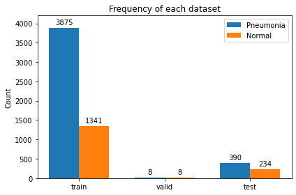

```python
labels = ['train', 'valid', 'test']
pneumonia = [len(train_pneumonia), len(val_pneumonia), len(test_pneumonia)]
normal = [len(train_normal), len(val_normal), len(test_normal)]

x = np.arange(len(labels))  # the label locations
width = 0.35  # the width of the bars

fig, ax = plt.subplots()
rects1 = ax.bar(x - width/2, pneumonia, width, label='Pneumonia')
rects2 = ax.bar(x + width/2, normal, width, label='Normal')

# Add some text for labels, title and custom x-axis tick labels, etc.
ax.set_ylabel('Count')
ax.set_title('Frequency of each dataset')
ax.set_xticks(x)
ax.set_ylim([0, 4200])
ax.set_xticklabels(labels)
ax.legend()


def autolabel(rects):
    """Attach a text label above each bar in *rects*, displaying its height."""
    for rect in rects:
        height = rect.get_height()
        ax.annotate('{}'.format(height),
                    xy=(rect.get_x() + rect.get_width() / 2, height),
                    xytext=(0, 3),  # 3 points vertical offset
                    textcoords="offset points",
                    ha='center', va='bottom')
autolabel(rects1)
autolabel(rects2)

fig.tight_layout()

plt.show()
```

**NOTE:** We can see that pneumonia images are in access almost 1:3 in ratio as compared to normal images. So, there is a class imbalance problem in our dataset. We need to consider it while preprocessing the images.

There is one more thing to notice, validation set consists of only 16 images, which is not good enough for model evaluation. So, we will need to make 80-20 split between train and validation set.

Let's plot some sample images of each class i.e. `Pneumonia` and `Normal` to see how these x-ray images look like.

#### 4.2 Review X-Ray Sample Images(Normal and Pneumonia)

#### 4.2.1 Review `Normal` X-Ray Sample Images(3)

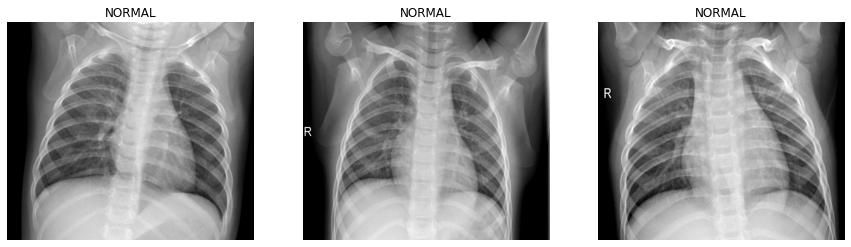

```python
# Normal X-Ray images
num_samples = 3
train_normal_samples = random.sample(train_normal, num_samples)

fig, axes = plt.subplots(1, num_samples, figsize=(15, 4))
for path, ax in zip(train_normal_samples, axes):
    img = plt.imread(TRAIN_DIR+'/NORMAL/'+path)
    ax.imshow(img, cmap='gray')
    ax.axis('off')
    ax.set_aspect('auto')
    ax.title.set_text('NORMAL')
plt.show()
```

#### 4.2.2 Review `Pneumonia` X-Ray Sample Images(3)

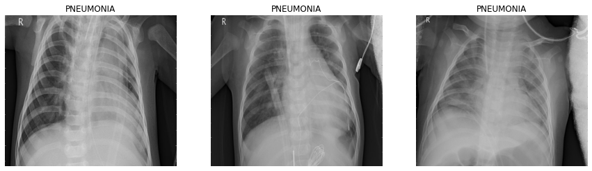

```python
# Pneumonia X-Ray images
train_pneumonia_samples = random.sample(train_pneumonia, num_samples)

fig, axes = plt.subplots(1, num_samples, figsize=(15, 4))
for path, ax in zip(train_pneumonia_samples, axes):
    img = plt.imread(TRAIN_DIR+'/PNEUMONIA/'+path)
    ax.imshow(img, cmap='gray')
    ax.axis('off')
    ax.set_aspect('auto')
    ax.title.set_text('PNEUMONIA')
plt.show()
```

```python
CLASS_NAMES = np.array([class_name.split(os.path.sep)[-1] for class_name in glob(os.path.join(TRAIN_DIR,"*"))])
CLASS_NAMES
```

```
array(['NORMAL', 'PNEUMONIA'], dtype='<U9')
```

#### 4.3 Pixel Intensity of `Pneumonia` and `Normal` Patient X-Ray Images

#### 4.3.1 Pixel Intensity of `Pneumonia` Patient X-Ray Images

```
Mean: 143.41, STD: 47.31
```

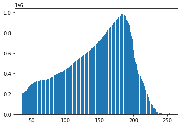

```python
# Pixel Intensity Distribution of Pneumonia Positive Cases
train_pneumonia_images = random.sample(train_pneumonia,100)
pneumonia_pixel = []
for img in train_pneumonia_images:
    img = io.imread(os.path.join(TRAIN_DIR,"PNEUMONIA",img)).ravel()
    # Remove Background Noise
    img_mask = [True if 35 < pixel < 255 else False for pixel in img]
    pneumonia_pixel.extend(img[img_mask])
print(f"Mean: {round(np.mean(pneumonia_pixel), 2)}, STD: {round(np.std(pneumonia_pixel), 2)}")
pneumonia_dist = plt.hist(pneumonia_pixel, bins=256);
```

#### 4.3.2 Pixel Intensity of `Non-Pneumonia` Patient X-Ray Images

```
Mean: 141.16, STD: 48.73
```

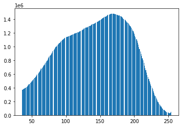

```python
# Pixel Intensity Distribution of Pneumonia Negative Cases
train_non_pneumonia_images = random.sample(train_normal,100)
non_pneumonia_pixel = []
for img in train_non_pneumonia_images:
    img = io.imread(os.path.join(TRAIN_DIR,"NORMAL",img)).ravel()
    # Remove Background Noise
    img_mask = [True if 35 < pixel < 255 else False for pixel in img]
    non_pneumonia_pixel.extend(img[img_mask])
print(f"Mean: {round(np.mean(non_pneumonia_pixel), 2)}, STD: {round(np.std(non_pneumonia_pixel), 2)}")
non_pneumonia_dist = plt.hist(non_pneumonia_pixel, bins=256);
```

```python
plt.savefig(f'Images/pneumonia_dist.png')
plt.savefig(f'Images/non_pneumonia_dist.png')
```

There is no significant difference between the intensity values of `Pneumonia` vs `Non-Pneumonia` Cases when looking at entire image. May be I need to focus on lungs to identify the difference.

#### 4.4 Exploration of Single Pneumonia Patient Image

#### Pneumonia Patient X-Ray Image

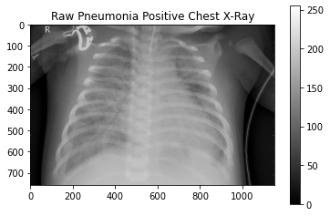

```python
# Investigate a Single Image
# Get the First Pneumonia Image that was in the DataFrame
sample_img = os.path.join(TRAIN_DIR,'PNEUMONIA',train_pneumonia[0])
raw_image = plt.imread(sample_img)
plt.imshow(raw_image, cmap='gray')
plt.colorbar();
plt.title('Raw Pneumonia Positive Chest X-Ray');
```

```python
print(f"The Dimension of the Image are {raw_image.shape[0]} pixels width and {raw_image.shape[1]} pixels height, one single color channel.")
print(f"The Maximum pixel value is {raw_image.max():.4f} and the minimum is {raw_image.min():.4f}")
print(f"The Mean Value of the Pixels is {raw_image.mean():.4f} and the Standard Deviation is {raw_image.std():.4f}")
```

```
The Dimension of the Image are 760 pixels width and 1152 pixels height, one single color channel.
The Maximum pixel value is 255.0000 and the minimum is 0.0000
The Mean Value of the Pixels is 114.5373 and the Standard Deviation is 56.2341
```

#### Pixel Intensity Values of Single Pneumonia Patient X-Ray Image

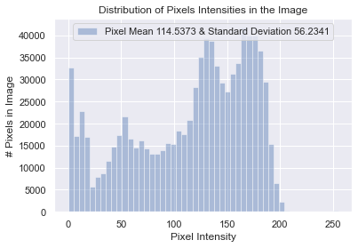

```python
# Plot a Histogram of the distribution
sns.set()
sns.distplot(raw_image.ravel(), label=f"Pixel Mean {np.mean(raw_image):.4f} & Standard Deviation {np.std(raw_image):.4f}", kde=False)
plt.legend(loc='upper center')
plt.title('Distribution of Pixels Intensities in the Image')
plt.xlabel('Pixel Intensity')
plt.ylabel('# Pixels in Image');
```

#### 4.5 EDA Findings

**Exploration of Pneumonia Cases:** In this section, I have found that 73% of the whole dataset forms `Pneumonia` cases and rest 27% are `Normal`.

So, we need to take care of class imbalance problem when feeding data to the model.

### 5. Preprocessing

```python
IMAGE_SIZE = (128, 128)
BATCH_SIZE = 8
EPOCHS = 30
VALIDATION_PCT = 0.20
```

**NOTE:** There are only 16 images in the validation set, which are very less as compared to training set. So, we need to append validation set with training set and create a new split that resembles the considerable 80:20 Split Instead.

```python
def get_label(file_path):
    return 1 if file_path.split(os.path.sep)[-2] == "PNEUMONIA" else 0
```

```python
filenames = glob(os.path.join(TRAIN_DIR, "*", "*"))
filenames.extend(glob(os.path.join(VALID_DIR, "*", "*")))
```

```python
all_data = []
for path in filenames:
    label = get_label(path)
    all_data.append((path, label))

all_data = pd.DataFrame(all_data, columns=['Path','Pneumonia'], index=None)
all_data = all_data.sample(frac=1.).reset_index(drop=True)
```

```python
# 80-20 split into train and validation set
train_set, val_set = train_test_split(all_data, test_size=0.20, stratify=all_data['Pneumonia'])
```

```python
# Number of images in train set
train_post_count = train_set['Pneumonia'].value_counts()
print(train_post_count)
```

```
1    3106
0    1079
Name: Pneumonia, dtype: int64
```

```python
# Number of images in validation set
val_post_count = val_set['Pneumonia'].value_counts()
print(val_post_count)
```

```
1    777
0    270
Name: Pneumonia, dtype: int64
```

```python
print(f'Total Pneumonia Cases: {all_data[all_data.Pneumonia==1].shape[0]}')
print(f'{(1-VALIDATION_PCT)*100}% Pneumonia Cases: {int(all_data[all_data.Pneumonia==1].shape[0]*(1-VALIDATION_PCT))}')
print(f'{VALIDATION_PCT*100}% Pneumonia Cases: {int(all_data[all_data.Pneumonia==1].shape[0]*VALIDATION_PCT)}')
print()
print(f'Pneumonia Cases in Training set: {train_set[train_set.Pneumonia==1].shape[0]}')
print(f'Pneumonia Cases in Validation set: {val_set[val_set.Pneumonia==1].shape[0]}')
print()
print(f'Train Set Size: {train_set.shape[0]}')
print(f'Pos %: {train_set[train_set.Pneumonia==1].shape[0] / train_set.shape[0] *100:.2f}')
print(f'Neg %: {train_set[train_set.Pneumonia==0].shape[0] / train_set.shape[0] *100:.2f}')
print()
print(f'Validation Set Size: {val_set.shape[0]}')
print(f'Pos %: {val_set[val_set.Pneumonia == 1].shape[0] / val_set.shape[0] *100:.2f}')
print(f'Neg % {val_set[val_set.Pneumonia == 0].shape[0] / val_set.shape[0] *100:.2f}')
```

```
Total Pneumonia Cases: 3883
80.0% Pneumonia Cases: 3106
20.0% Pneumonia Cases: 776

Pneumonia Cases in Training set: 3106
Pneumonia Cases in Validation set: 777

Train Set Size: 4185
Pos %: 74.22
Neg %: 25.78

Validation Set Size: 1047
Pos %: 74.21
Neg % 25.79
```

```python
test_files = glob(os.path.join(TEST_DIR,'*','*'))
```

```python
test_set = []
for path in test_files:
    label = get_label(path)
    test_set.append((path, label))

test_set = pd.DataFrame(test_set, columns=['Path', 'Pneumonia'], index=None)
test_set = test_set.sample(frac=1.).reset_index(drop=True)
```

#### 5.1 Defining Train, Val and Test Generators

- We are defining a train generator to modify the images before feeding it into the model. For this task we'll use the Keras [ImageDataGenerator](https://keras.io/preprocessing/image/) function to perform data preprocessing and data augmentation.
- The `image_generator` will adjust our image data such that the new mean of the data will be zero, and the standard deviation of the data will be 1. In other words, the generator will replace each pixel value in the image with a new value calculated by subtracting the mean and dividing by the standard deviation.

$$\frac{x_i - \mu}{\sigma}$$

- We are also reducing the image size down to 128*128 pixels.
- We are using data augmentation to avoid overfitting. `Data augmentation` is a strategy that helps to significantly increase the diversity of data available for training models, without actually collecting new data.

```python
def get_train_generator(df, x_col, y_col, shuffle=True, batch_size=BATCH_SIZE, seed=1, target_w = 128, target_h = 128):
    """
    Return generator for training set, normalizing using batch
    statistics.

    Args:
      train_df (dataframe): dataframe specifying training data.
      x_col (str): name of column in df that holds filenames.
      y_col (list): name of column in df as target
      sample_size (int): size of sample to use for normalization statistics.
      batch_size (int): images per batch to be fed into model during training.
      seed (int): random seed.
      target_w (int): final width of input images.
      target_h (int): final height of input images.

    Returns:
        train_generator (DataFrameIterator): iterator over training set
    """
    print("[INFO] Getting Train Generator...")
    # Normalize images
    image_generator = ImageDataGenerator(
        samplewise_center=True,
        samplewise_std_normalization= True,
        shear_range=0.1,
        zoom_range=0.15,
        rotation_range=5,
        width_shift_range=0.1,
        height_shift_range=0.05,
        horizontal_flip=True,
        vertical_flip = False,
        fill_mode = 'reflect')

    # Flow from directory with specified batch size
    # and target image size
    generator = image_generator.flow_from_dataframe(
            dataframe=df,
            directory=None,
            x_col=x_col,
            y_col=y_col,
            class_mode="raw",
            batch_size=batch_size,
            shuffle=shuffle,
            seed=seed,
            target_size=(target_w,target_h))
    return generator
```

Now we need to build a new generator for validation and test set. We cannot use the same generator as for training data because it normalizes each image per batch. In real life scenario we don't process incoming images a batch at a time instead we process one image at a time.

```python
def get_test_and_valid_generator(valid_df, test_df, train_df, x_col, y_col, sample_size=100, batch_size=BATCH_SIZE, seed=1, target_w = 128, target_h = 128):
    """
    Return generator for validation set and test test set using
    normalization statistics from training set.

    Args:
      valid_df (dataframe): dataframe specifying validation data.
      test_df (dataframe): dataframe specifying test data.
      train_df (dataframe): dataframe specifying training data.
      x_col (str): name of column in df that holds filenames.
      y_col (list): name of column in df as target.
      sample_size (int): size of sample to use for normalization statistics.
      batch_size (int): images per batch to be fed into model during training.
      seed (int): random seed.
      target_w (int): final width of input images.
      target_h (int): final height of input images.

    Returns:
        test_generator (DataFrameIterator) and valid_generator: iterators over test set and validation set respectively
    """
    print("[INFO] Getting Valid and Test Generators...")
    # Get generator to sample dataset
    raw_train_generator = ImageDataGenerator().flow_from_dataframe(
        dataframe=train_df,
        directory=None,
        x_col=x_col,
        y_col=y_col,
        class_mode="raw",
        batch_size=sample_size,
        shuffle=True,
        target_size=(target_w, target_h))

    # Get data sample
    batch = raw_train_generator.next()
    data_sample = batch[0]

    # Use sample to fit mean and std for test set generator
    image_generator = ImageDataGenerator(featurewise_center=True,
        featurewise_std_normalization= True)

    # Fit generator to sample from training data
    image_generator.fit(data_sample)

    # Get Valid Generator
    valid_generator = image_generator.flow_from_dataframe(
            dataframe=valid_df,
            directory=None,
            x_col=x_col,
            y_col=y_col,
            class_mode="raw",
            batch_size=batch_size,
            shuffle=False,
            seed=seed,
            target_size=(target_w,target_h))
    # Get Test Generator
    test_generator = image_generator.flow_from_dataframe(
            dataframe=test_df,
            directory=None,
            x_col=x_col,
            y_col=y_col,
            class_mode="raw",
            batch_size=batch_size,
            shuffle=False,
            seed=seed,
            target_size=(target_w,target_h))
    return valid_generator, test_generator
```

```python
train_generator = get_train_generator(train_set, "Path", "Pneumonia")
```

```
[INFO] Getting Train Generator...
Found 4185 validated image filenames.
```

```python
valid_generator, test_generator = get_test_and_valid_generator(val_set, test_set, train_set, "Path", "Pneumonia")
```

```
[INFO] Getting Valid and Test Generators...
Found 4185 validated image filenames.
Found 1047 validated image filenames.
Found 624 validated image filenames.
```

Let's see how an image looks like after using generator.

```
Clipping input data to the valid range for imshow with RGB data ([0..1] for floats or [0..255] for integers).
```

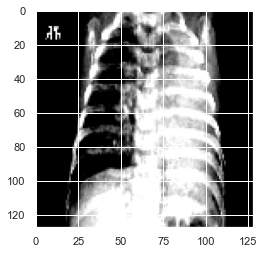

```python
x, y = train_generator.__getitem__(0)
plt.imshow(x[0]);
```

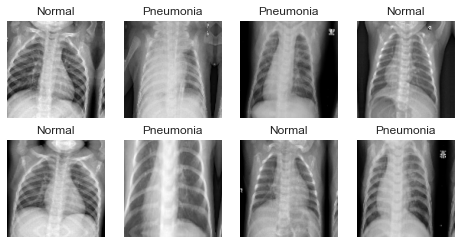

```python
t_x, t_y = next(train_generator)
fig, m_axs = plt.subplots(2, 4, figsize = (8, 4))
for (c_x, c_y, c_ax) in zip(t_x, t_y, m_axs.flatten()):
    c_ax.imshow(c_x[:,:,0], cmap = 'gray')
    if c_y == 1:
        c_ax.set_title('Pneumonia')
    else:
        c_ax.set_title('Normal')
    c_ax.axis('off')
```

#### 5.2 Addressing Class Imbalance Problem using Class Weights

```python
def compute_class_freqs(labels):
    """
    Compute positive and negative frequences for each class.

    Args:
        labels (np.array): matrix of labels, size (num_examples, num_classes)
    Returns:
        positive_frequencies (np.array): array of positive frequences for each
                                         class, size (num_classes)
        negative_frequencies (np.array): array of negative frequences for each
                                         class, size (num_classes)
    """
    # Total number of patients (rows)
    N = labels.shape[0]

    positive_frequencies = np.sum(labels, axis=0) / N
    negative_frequencies = 1 - positive_frequencies

    return positive_frequencies, negative_frequencies
```

```python
# Computing class frequencies for our training set
freq_pos, freq_neg = compute_class_freqs(train_generator.labels)
pos_weights = freq_neg
neg_weights = freq_pos
class_weights = {0: neg_weights, 1:pos_weights}
```

#### 5.3 DenseNet121

Now we will use a pre-trained DenseNet121 model. We will add two more layers on top of it.

- `GlobalAveragePooling2D` to get the average of the last layer of DenseNet121.
- `Dense` layer to get predictions.

```python
def setup_densenet_pretrained_model():
    # Create the base pre-trained model
    base_model = DenseNet121(weights='nih/densenet.hdf5', include_top=False)

    x = base_model.output

    # Add a global spatial average pooling layer
    x = GlobalAveragePooling2D()(x)

    # And a logistic layer
    predictions = Dense(1, activation="sigmoid")(x)

    model = Model(inputs=base_model.input, outputs=predictions)

    return model
```

#### 5.4 Defining Model Checkpoints

We are defining some callback function which will helps us to view on internal states and statistics of the model during training so that we can fix bugs more quickly. Callbacks used are:

- `CSVLogger:` We are defining a callback for logging every epoch result into a csv file.
- `EarlyStopping:` EarlyStopping is used to avoid overfitting and terminate the process early if it is the case. Here, patience level is 10 means it waits for 10 epochs, if no change is noticed then it will automatically terminate the learning process.
- Our callback is also keeping an eye on the `val_loss` metric at the point.
- Checkpoint also saves the best fit model.

```python
x_ray_class = "Pneumonia_Detection_Model_Dense_FINAL_ATTEMPT"
_time = time.localtime()
prefix = time.strftime("%m_%d_%Y_%H_%M")

weight_path = f"Model_Checkpoints/{x_ray_class}_{prefix}_model_best.hdf5"

cb_checkpoint = ModelCheckpoint(weight_path,
                            monitor = 'val_loss',
                            verbose=1,
                            save_best_only=True,
                            mode='min',
                            save_weights_only=True)

cb_early = EarlyStopping(monitor='val_loss',
                     mode='min',
                     patience=10)

cb_csv_logger = CSVLogger(f'Logs/{x_ray_class}_{prefix}_log.csv', append=True, separator=';')
```

```python
LRSchedular = False
if LRSchedular:
    def exponential_decay(lr0, s):
        def exponential_decay_fn(epoch):
            return lr0 * 0.1 **(epoch / s)
        return exponential_decay_fn

    exponential_decay_fn = exponential_decay(0.01, 20)

    lr_scheduler = tf.keras.callbacks.LearningRateScheduler(exponential_decay_fn)
    print(f"Callback created with Checkpoint, LearningRateScheduler and EarlyStopping !")
    call_backs_list = [cb_checkpoint, cb_early, lr_scheduler]
else:
    print(f"Callback created with Checkpoint and EarlyStopping !")
    call_backs_list = [cb_checkpoint, cb_early, cb_csv_logger]
```

```
Callback created with Checkpoint and EarlyStopping !
```

Let's start the training process, it will take some time.

```python
run_custom_training = False
if run_custom_training:
    t_start = time.time()
    print(f"[INFO] Model Training Started : {time.ctime(t_start)}")
    history = model.fit(train_generator,
                        steps_per_epoch=len(train_generator),
                        epochs=10,
                        validation_data=valid_generator,
                        validation_steps=len(valid_generator),
                        class_weight=class_weights,
                        callbacks = call_backs_list)
    model.load_weights(weight_path)
    print(f"[INFO] Model Training Finished : {time.ctime(time.time())}")
    model.save("Models/Pneumonia_Detection_Model_Final_Dense_FINAL_ATTEMPT.h5")
    print(f"[INFO] Model Saved")
    t_finish = time.time()
    print(f'Training took {(t_finish - t_start) // 60} minutes')
    plt.plot(history.history['loss'])
    plt.ylabel("loss")
    plt.xlabel("epoch")
    plt.title("Training Loss Curve")
    plt.show()
```

```python
print("[INFO] Compiling Model...")
model_check_path = 'Model_Checkpoints/Pneumonia_Detection_Model_Dense_FINAL_ATTEMPT_10_01_2020_11_49_model_best.hdf5'
model = setup_densenet_pretrained_model()
model.load_weights(model_check_path)
print("[INFO] Weights has been Loaded to Model !")
METRICS = ['accuracy', AUC(), Precision(), Recall()]
model.compile(optimizer='adam', loss='binary_crossentropy', metrics=METRICS)
model_path = 'Models/Pneumonia_Detection_Model_Final_Dense_FINAL_ATTEMPT.h5'
model.save(model_path)
model.load_weights(model_path)
print("[INFO] Model Compiled...")
```

```
[INFO] Compiling Model...
[INFO] Weights has been Loaded to Model !
[INFO] Model Compiled...
```

#### 6. Prediction and Evaluation

Defining a function to get predictions out of our model for test set.

```python
# Functions for getting model predictions and plotting results
def get_model_predictions(model_filepath, data):
    """
    Takes in a filepath to the saved model, loads in the model, and gets predictions for all data sent in.
    :param model_filepath: filepath to a saved model, must have .h5 extension
    :param data: Data to make predictions on
    :return: True labels, predictions
    """
    model = tf.keras.models.load_model(model_filepath)
    pred_y = model.predict(data)
    return [data for answer in pred_y for data in answer]
```

```python
image_batch, true_y = next(iter(test_generator))
```

```python
pred_y = get_model_predictions(model_path, image_batch)
```

Setting a thresold to classify the X-Ray image as Pneumonia or Normal. As Medical Model should be high Recall model, therefore we are taking a threshold of 0.135.

```python
threshold = 0.135
pred_y_binary = [1.0 if pred > threshold else 0.0 for pred in pred_y]
pred_y_binary
```

```
[1.0, 0.0, 1.0, 1.0, 1.0, 1.0, 1.0, 1.0]
```

```python
# Create a confusion matrix and report performance statistics
matrix = confusion_matrix(true_y, pred_y_binary, labels=[1.0,0.0])
print(matrix)
TP, FN, FP, TN = matrix.flatten()
print(f'Recall: {TP/(TP+FN)*100:.2f}%')
print(f'Precision: {TP/(TP+FP)*100:.2f}%')
print(f'False Positive Rate: {FP/(FP+TN)*100:.2f}%')
```

```
[[6 0]
 [1 1]]
Recall: 100.00%
Precision: 85.71%
False Positive Rate: 50.00%
```

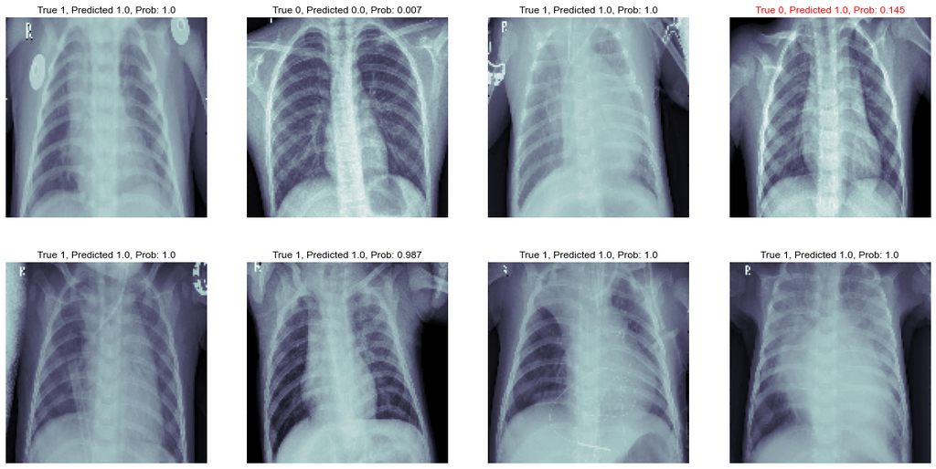

```python
## Look at a sample of predicted v. true values along with model probabilities:
fig, m_axs = plt.subplots(2, 4, figsize = (20, 10))
i = 0
for (c_x, c_y, c_ax) in zip(image_batch[0:8], true_y[0:8], m_axs.flatten()):
    c_ax.imshow(c_x[:,:,0], cmap = 'bone')
    prob = round(float(pred_y[i]),3)
    if c_y != pred_y_binary[i]:
        c_ax.set_title(f'True {c_y}, Predicted {pred_y_binary[i]}, Prob: {prob}', color = 'red')
    else:
        c_ax.set_title(f'True {c_y}, Predicted {pred_y_binary[i]}, Prob: {prob}', color = 'black')
    c_ax.axis('off')
    i=i+1
```

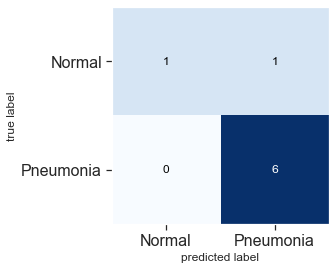

```python
# Get the Confusion Matrix
cm = confusion_matrix(true_y, pred_y_binary)
plt.figure()
plot_confusion_matrix(cm, figsize=(4,4), hide_ticks=True, cmap=plt.cm.Blues)
plt.xticks(range(2), ['Normal', 'Pneumonia'], fontsize=16)
plt.yticks(range(2), ['Normal', 'Pneumonia'], fontsize=16)
plt.savefig(f'Images/CM_Subset.png')
plt.show();
```

```python
predicted_vals = model.predict(test_generator, steps = len(test_generator))
```

```python
true_y = test_set['Pneumonia'].values
```

#### 6.1 Confusion Matrix

Confusion Matrix tells us about how our model is performing while classifying.

The diagonal elements of confusion matrix represent the number of points for which the predicted label is equal to the true label, while off-diagonal elements are those that are mislabeled by the classifier.

- True Positives(Bottom-Right) - Both actual and predicted values are Positive.
- True Negatives(Top-Left) - Both actual and predicted values are Negative.
- False Positives(Top-Right) - The actual value is negative but we predicted it as positive.
- False Negatives(Bottom-Left) - The actual value is positive but we predicted it as negative.

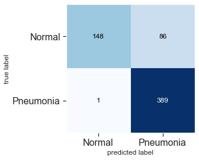

```python
threshold = 0.135
pred_y_binary = [1.0 if pred > threshold else 0.0 for pred in predicted_vals]
pred_y_binary
cm = confusion_matrix(true_y, pred_y_binary)
plt.figure()
plot_confusion_matrix(cm, figsize=(4,4), hide_ticks=True, cmap=plt.cm.Blues)
plt.xticks(range(2), ['Normal', 'Pneumonia'], fontsize=16)
plt.yticks(range(2), ['Normal', 'Pneumonia'], fontsize=16)
plt.savefig(f'Images/CM_Full_Test_Data.png')
plt.show();
```

- TP - 389
- TN - 148
- FP - 86
- FN - 1

Let's explore more about it by reviewing the accuracy, recall, precision on test set.

#### 6.2 Accuracy, Loss, AUC, Precision and Recall

```python
model_evaluation = model.evaluate(test_generator)
print(f"Loss of Model on Test Set: {model_evaluation[0]*100:.2f}%")
print(f"Accuracy of Model on Test Set: {model_evaluation[1]*100:.2f}%")
print(f"AUC of Model on Test Set: {model_evaluation[2]*100:.2f}%")
print(f"Precision of Model on Test Set: {model_evaluation[3]*100:.2f}%")
print(f"Recall of Model on Test Set: {model_evaluation[4]*100:.2f}%")
```

```
Loss of Model on Test Set: 45.46%
Accuracy of Model on Test Set: 90.22%
AUC of Model on Test Set: 93.52%
Precision of Model on Test Set: 87.64%
Recall of Model on Test Set: 98.21%
```

Load the log file to see the validation statistics

```python
history_logs = pd.read_csv('Logs/Pneumonia_Detection_Model_Dense_FINAL_ATTEMPT_10_01_2020_11_49_log.csv',sep=';')
history_logs
```

|  | epoch | accuracy | auc | loss | precision | recall | val_accuracy | val_auc | val_loss | val_precision | val_recall |
| --- | --- | --- | --- | --- | --- | --- | --- | --- | --- | --- | --- |
| 0 | 0 | 0.868578 | 0.935721 | 0.127875 | 0.956103 | 0.862524 | 0.676218 | 0.980724 | 0.724194 | 0.995475 | 0.566281 |
| 1 | 1 | 0.909200 | 0.969362 | 0.085620 | 0.974582 | 0.901159 | 0.784145 | 0.964226 | 0.833485 | 1.000000 | 0.709138 |
| 2 | 2 | 0.911828 | 0.969646 | 0.084824 | 0.971409 | 0.907920 | 0.945559 | 0.990290 | 0.146556 | 0.985175 | 0.940798 |
| 3 | 3 | 0.919713 | 0.976276 | 0.075135 | 0.976928 | 0.913393 | 0.897803 | 0.982692 | 0.234649 | 0.986919 | 0.873874 |
| 4 | 4 | 0.925926 | 0.978713 | 0.070360 | 0.978439 | 0.920476 | 0.860554 | 0.984806 | 0.340659 | 0.993740 | 0.817246 |
| 5 | 5 | 0.933572 | 0.978025 | 0.070083 | 0.977703 | 0.931745 | 0.944604 | 0.985509 | 0.138514 | 0.969935 | 0.954955 |
| 6 | 6 | 0.945281 | 0.986561 | 0.054336 | 0.984507 | 0.941082 | 0.927412 | 0.987790 | 0.216799 | 0.995757 | 0.906049 |
| 7 | 7 | 0.944564 | 0.985086 | 0.057232 | 0.982539 | 0.942048 | 0.905444 | 0.983803 | 0.290948 | 0.992733 | 0.879022 |
| 8 | 8 | 0.946953 | 0.987236 | 0.053537 | 0.984543 | 0.943335 | 0.954155 | 0.991444 | 0.129723 | 0.985353 | 0.952381 |

#### 6.3 Accuracy and Loss Curve of Training and Validation Set

```python
# Plot Model History
def plot_history(model_history, model_name):
    N = len(model_history['loss'])
    plt.style.use('ggplot')
    plt.figure()
    plt.plot(np.arange(0,N), model_history['loss'], label='train loss')
    plt.plot(np.arange(0,N), model_history['val_loss'], label='valuation loss')
    plt.plot(np.arange(0,N), model_history['accuracy'], label='train accuracy')
    plt.plot(np.arange(0,N), model_history['val_accuracy'], label='valuation accuracy')
    plt.title("Model Training Results")
    plt.xlabel("Epoch #")
    plt.ylabel("Loss \ Accuracy")
    plt.legend(loc="upper left")
    plt.savefig(f'Images/{model_name}_history.png')
    plt.plot()
```

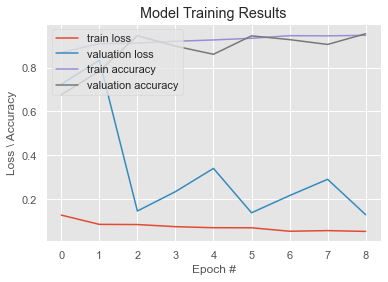

```python
plot_history(history_logs, "DenseNet")
```

#### 6.4 ROC Curve, Precision-Recall Curve, F1 Score

```python
def plot_roc_curve(model_name, true_y, pred_y):
    """
    Plot the ROC curve along with the curves AUC for a given model. Note make sure true_y and pred_y are from the same model as model_name
    :param model_name: Name of model used for saving plot
    :param true_y: true labels for dataset
    :param pred_y: predicted labels for dataset
    """
    fig, ax = plt.subplots(1,1, figsize=(7,7))
    fpr, tpr, thresholds = sklearn.metrics.roc_curve(true_y, pred_y)
    ax.plot(fpr, tpr, label=f'{model_name} AUC: {sklearn.metrics.auc(fpr,tpr)}')
    ax.legend()
    ax.set_xlabel("False Positive Rate")
    ax.set_ylabel("True Positive Rate")
    plt.savefig(f'Images/{model_name}_roc.png')
    return

def plot_precision_recall_curve(model_name, true_y, pred_y):
    """
    Plot the precision recall curve for a given model. Note make sure true_y and pred_y are from the same model as model_name
    :param model_name: Name of model used for saving plot
    :param true_y: true labels for dataset
    :param pred_y: predicted labels for dataset
    """
    fig, ax = plt.subplots(1,1, figsize=(7,7))
    precision, recall, thresholds = precision_recall_curve(true_y, pred_y)
    ax.plot(recall, precision, label=f'{model_name} AP Score: {sklearn.metrics.average_precision_score(true_y,pred_y)}')
    plt.legend()
    ax.set_xlabel("Recall")
    ax.set_ylabel("Precision")
    plt.savefig(f'Images/{model_name}_precision_recall.png')
    return

def calculate_f1_scores(precision, recall):
    return [(2*p*r)/(p+r) for p,r in zip(precision,recall)]

def plot_f1_score(model_name, true_y, pred_y):
    """
    Plot F1 Scores for a given model. Note make sure true_y and pred_y are from the same model as model_name
    F1 = 2*(precision*recall) / (precision + recall)
    :param model_name: Name of model used for saving plot
    :param true_y: true labels for dataset
    :param pred_y: predicted labels for the dataset
    """
    fig, ax = plt.subplots(1,1,figsize=(7,7))
    precision, recall, thresholds = precision_recall_curve(true_y,pred_y)
    ax.plot(thresholds, precision[:-1], label=f'{model_name} Precision')
    ax.plot(thresholds, recall[:-1], label=f'{model_name} Recall')
    f1_scores = calculate_f1_scores(precision, recall)[:-1]
    ax.plot(thresholds, f1_scores, label=f'{model_name} F1 Score')
    plt.legend()
    ax.set_xlabel("Threshold Values")
    plt.savefig(f'Images/{model_name}_f1_score.png')
    return max(f1_scores)
```

```python
predicted_vals = model.predict(test_generator, steps = len(test_generator))
```

```python
true_y = test_set['Pneumonia'].values
```

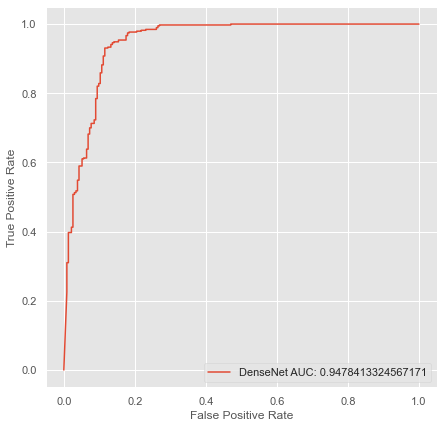

```python
plot_roc_curve("DenseNet", true_y, predicted_vals)
```

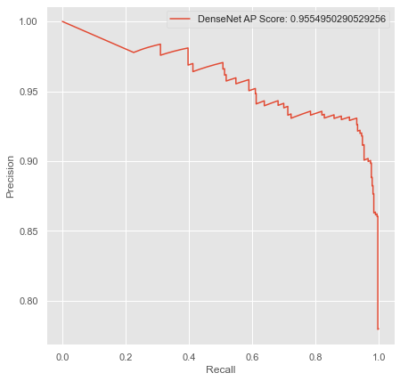

```python
plot_precision_recall_curve("DenseNet", true_y, predicted_vals)
```

```
0.936117936117936
```

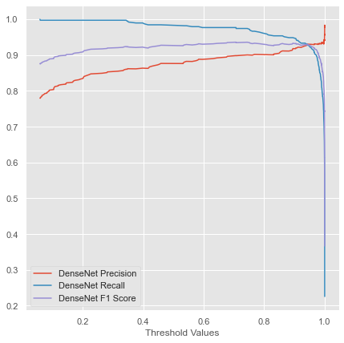

```python
plot_f1_score('DenseNet', true_y, predicted_vals)
```

#### 6.5 Visualize Model Learning with GradCAM

Gradient Class Activation Maps(GradCAM) are very useful for understanding where the model is looking on a particular layer when classifying an image.

Below we have applied this technique to visualize the model learning. This is done by extracting the gradients of each predicted class, flowing into our model's final convolution layer.

We will use GradCAM's technique to produce heatmap highlighting the important regions in the image for predicting the disease.

```python
def get_mean_std_per_batch(df, H=128, W=128):
    sample_data = []
    for idx, img in enumerate(df.sample(100)["Path"].values):
        sample_data.append(
            np.array(image.load_img(img, target_size=(H, W))))
    mean = np.mean(sample_data[0])
    std = np.std(sample_data[0])
    return mean, std


def load_image(img, df, preprocess=True, H=128, W=128):
    """Load and preprocess image."""
    mean, std = get_mean_std_per_batch(df, H=H, W=W)
    x = image.load_img(img, target_size=(H, W))
    if preprocess:
        x -= mean
        x /= std
        x = np.expand_dims(x, axis=0)
    return x


def grad_cam(input_model, image, cls, H=128, W=128):
    """GradCAM method for visualizing input saliency."""
    y_c = input_model.output[0, cls]
    conv_output = input_model.get_layer('bn').output
    grads = K.gradients(y_c, conv_output)[0]
    gradient_function = K.function([input_model.input], [conv_output, grads])

    output, grads_val = gradient_function([image])
    output, grads_val = output[0, :], grads_val[0, :, :, :]
    weights = np.mean(grads_val, axis=(0, 1))
    cam = np.dot(output, weights)

    # Process CAM
    cam = cv2.resize(cam, (W, H), cv2.INTER_LINEAR)
    cam = np.maximum(cam, 0)
    cam = cam / cam.max()
    return cam


def compute_gradcam(model, img, df, labels, selected_labels):
    preprocessed_input = load_image(img, df)
    predictions = model.predict(preprocessed_input)
    print("Loading Original Image...")
    plt.figure(figsize=(15, 10))
    plt.subplot(151)
    plt.title("Original")
    plt.axis('off')
    plt.imshow(load_image(img, df, preprocess=False), cmap='gray')

    j = 1
    for i in range(len(labels)):
        if labels[i] in selected_labels:
            print(f"Generating Gradcam for Class {labels[i]}")
            gradcam = grad_cam(model, preprocessed_input, i)
            plt.subplot(151 + j)
            plt.title(f"{labels[i]}: Prob={predictions[0][i]:.3f}")
            plt.axis('off')
            plt.imshow(load_image(img, df, preprocess=False), cmap='gray')
            plt.imshow(gradcam, cmap='jet', alpha=min(0.5, predictions[0][i]))
            j += 1
```

```python
labels, labels_to_show = ['Pneumonia'], ['Pneumonia']
```

Looking at the specific images including `NORMAL` as well as `PNEUMONIA` cases.

```
Original - PNEUMONIA
Loading Original Image...
Generating Gradcam for Class Pneumonia
```

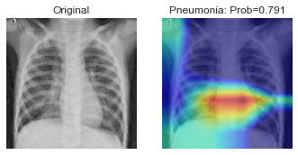

```python
print("Original - PNEUMONIA")
compute_gradcam(model, 'G:\\Downloads\\archive\\chest_xray\\test\\PNEUMONIA\\person20_virus_51.jpeg', train_set, labels, labels_to_show)
```

```
Original - NORMAL
Loading Original Image...
Generating Gradcam for Class Pneumonia
```

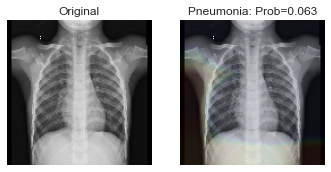

```python
print("Original - NORMAL")
compute_gradcam(model, 'G:\\Downloads\\archive\\chest_xray\\test\\NORMAL\\NORMAL2-IM-0051-0001.jpeg', train_set, labels, labels_to_show)
```

```
Original - PNEUMONIA
Loading Original Image...
Generating Gradcam for Class Pneumonia
```

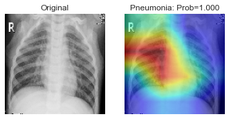

```python
print("Original - PNEUMONIA")
compute_gradcam(model, 'G:\\Downloads\\archive\\chest_xray\\test\\PNEUMONIA\\person44_virus_93.jpeg', train_set, labels, labels_to_show)
```

```
Original - NORMAL
Loading Original Image...
Generating Gradcam for Class Pneumonia
```

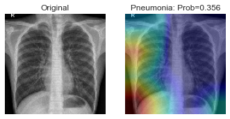

```python
print("Original - NORMAL")
compute_gradcam(model, 'G:\\Downloads\\archive\\chest_xray\\test\\NORMAL\\IM-0041-0001.jpeg', train_set, labels, labels_to_show)
```

```
Original - PNEUMONIA
Loading Original Image...
Generating Gradcam for Class Pneumonia
```

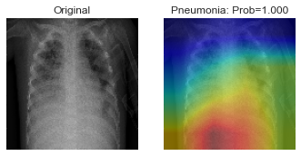

```python
print("Original - PNEUMONIA")
compute_gradcam(model, 'G:\\Downloads\\archive\\chest_xray\\test\\PNEUMONIA\\person1661_virus_2872.jpeg', train_set, labels, labels_to_show)
```

```
Original - NORMAL
Loading Original Image...
Generating Gradcam for Class Pneumonia
```

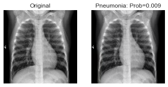

```python
print("Original - NORMAL")
compute_gradcam(model, 'G:\\Downloads\\archive\\chest_xray\\test\\NORMAL\\NORMAL2-IM-0374-0001.jpeg', train_set, labels, labels_to_show)
```

```
Original - PNEUMONIA
Loading Original Image...
Generating Gradcam for Class Pneumonia
```

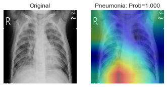

```python
print("Original - PNEUMONIA")
compute_gradcam(model, 'G:\\Downloads\\archive\\chest_xray\\test\\PNEUMONIA\\person1679_virus_2896.jpeg', train_set, labels, labels_to_show)
```